# All_SnapPantModel

### Confusion Matrix - Overall View

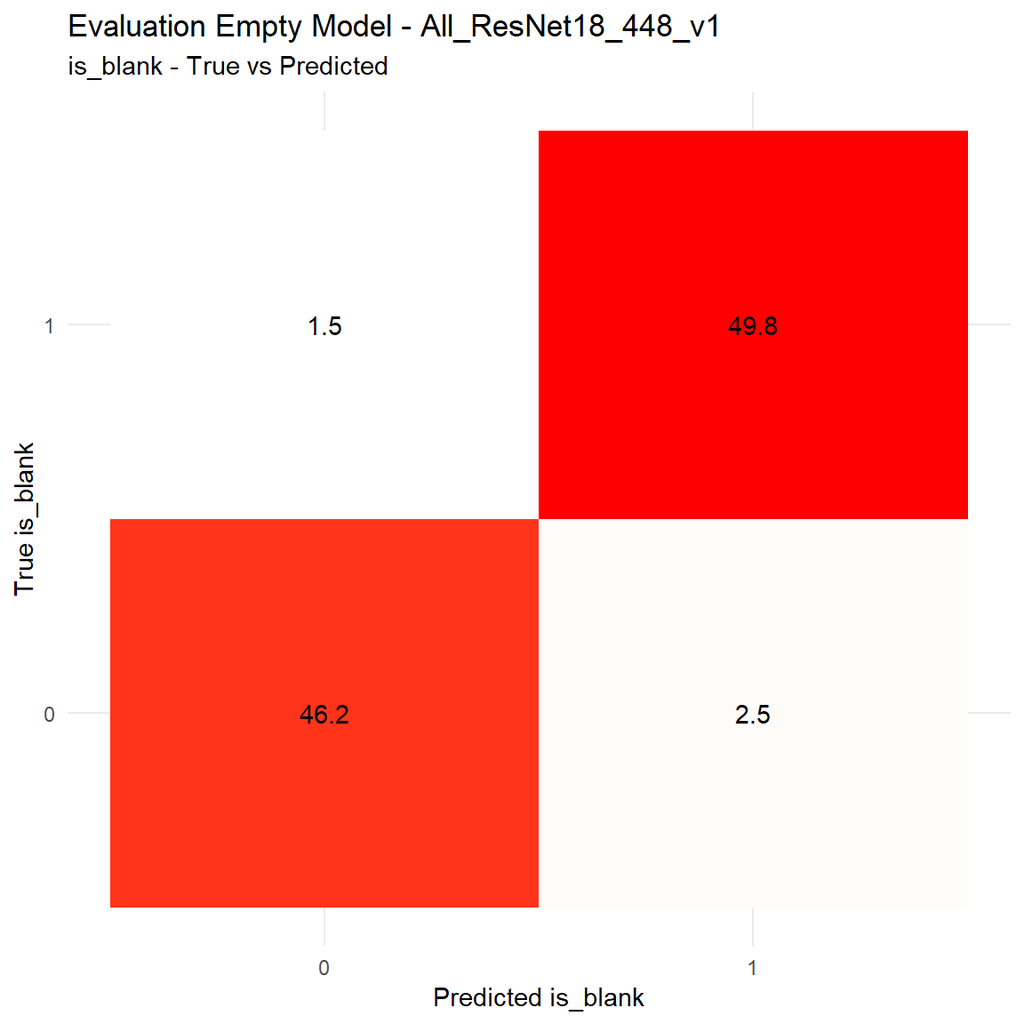

### Confusion Matrix - Per Label(row) View

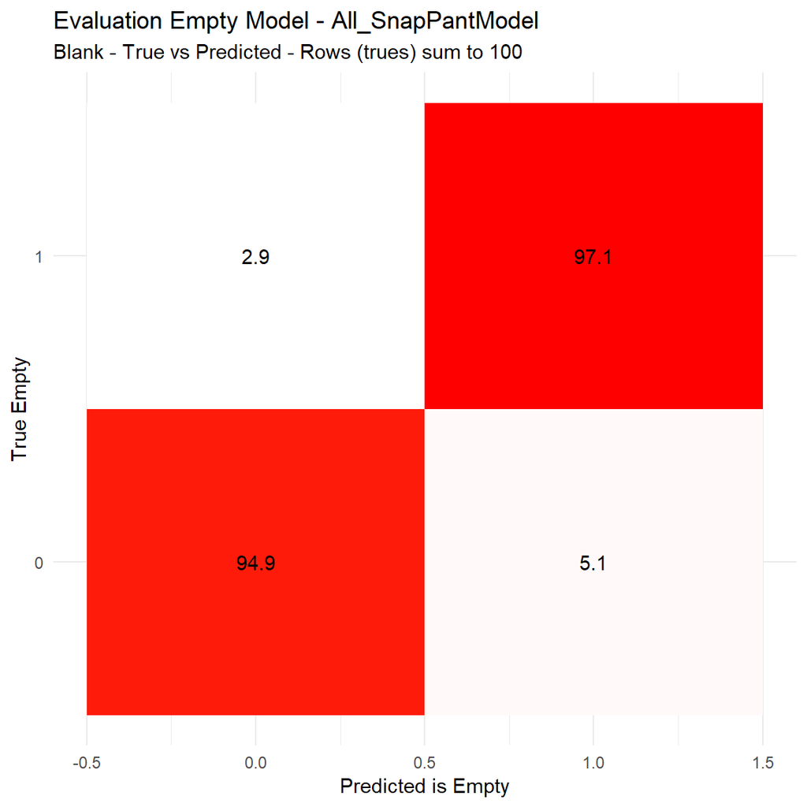

## Species-Model Evaluations

The following figures show evaluations of the ‘Species’ model.

### Per Location

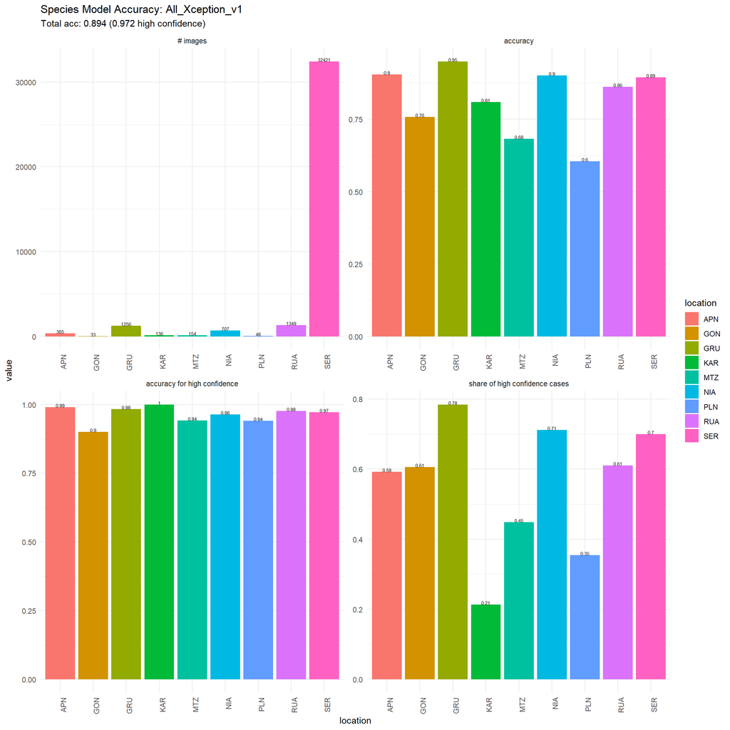

### Per Species

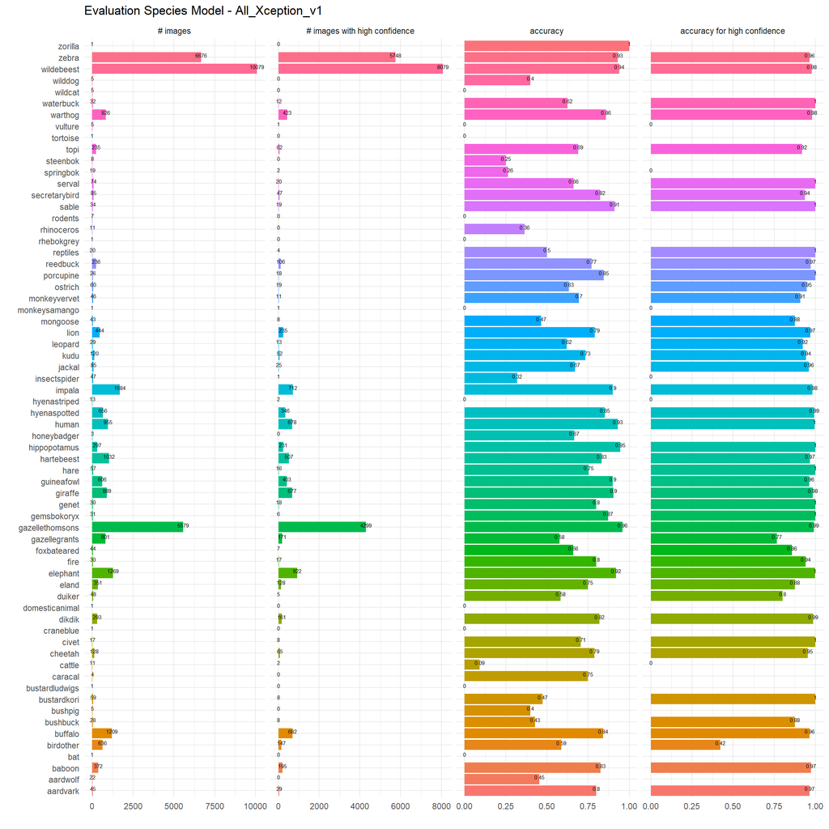

### Counts Evaluations

The following figures show evaluations of predicted counts.

#### Overall View

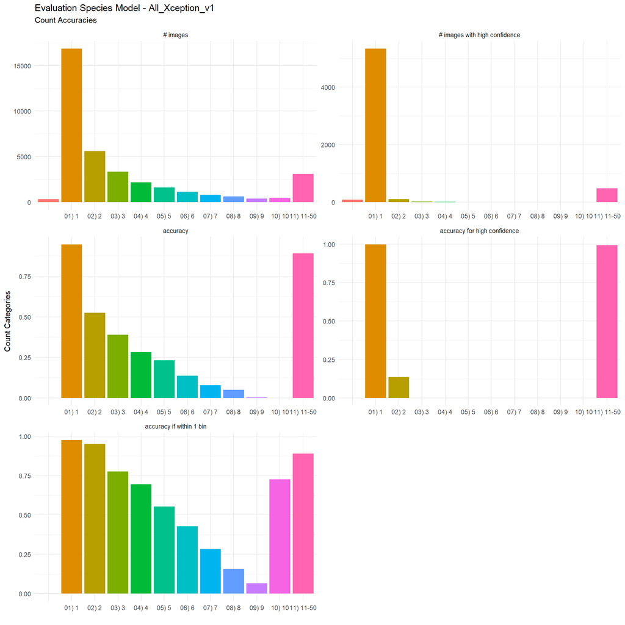

#### Confusion Matrix - Absolute Values

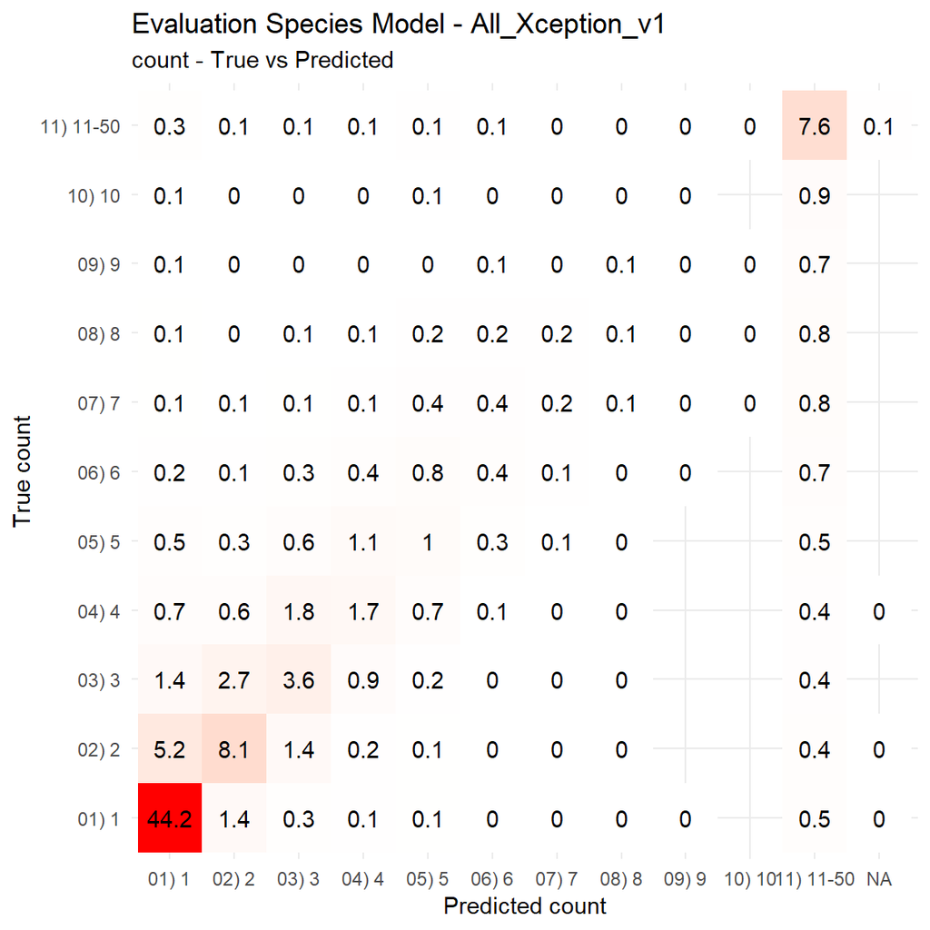

#### Confusion Matrix - Relative Values

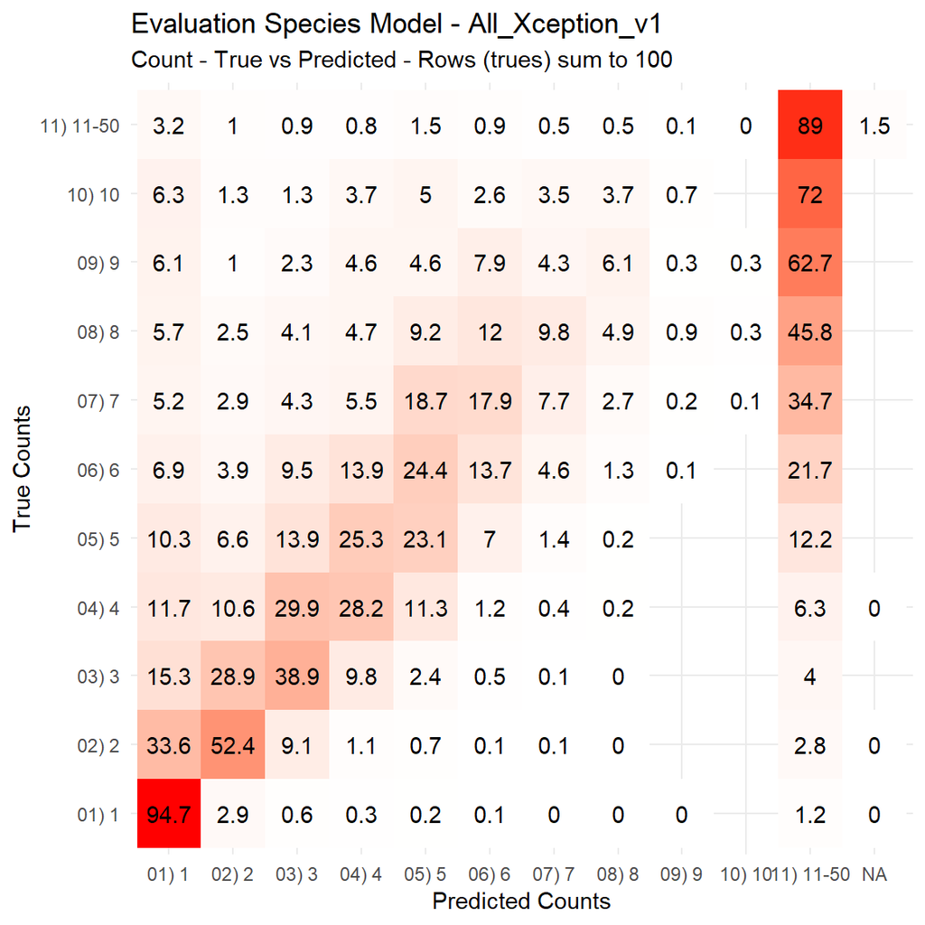

### Behavior Evaluation - Standing

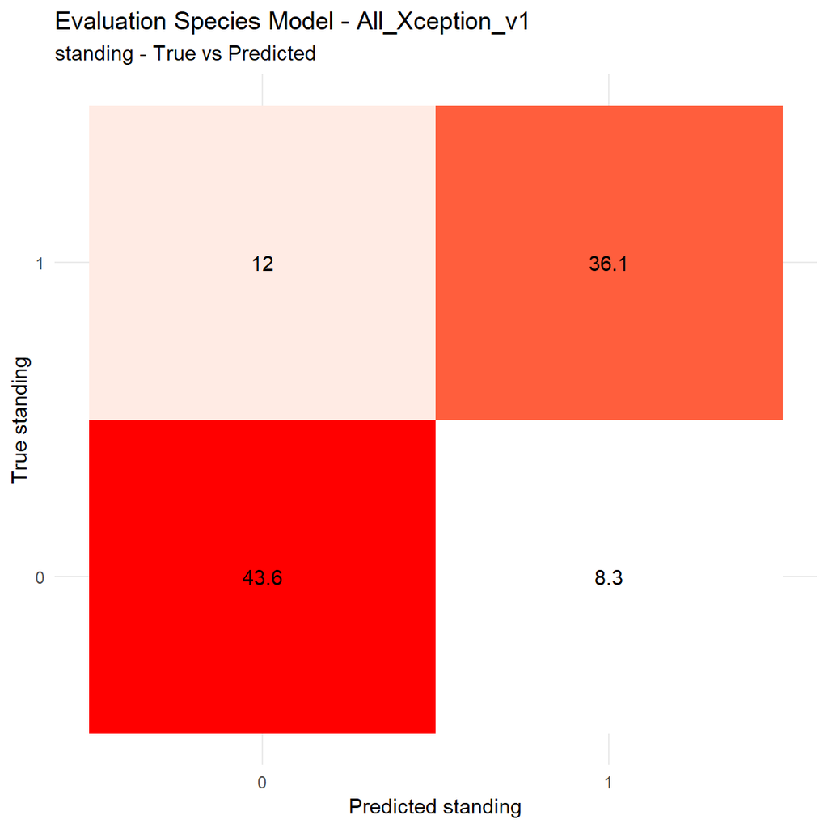

### Behavior Evaluation - Moving

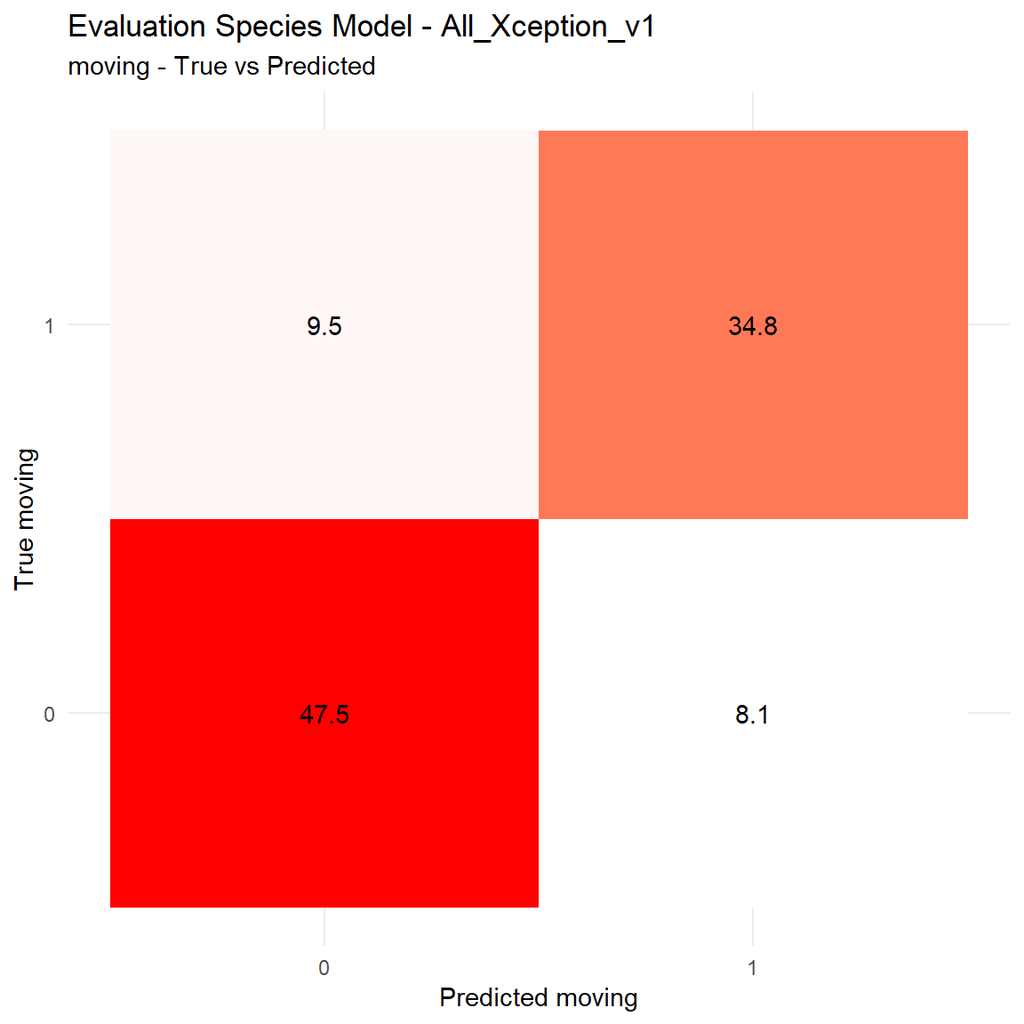

### Behavior Evaluation - Eating

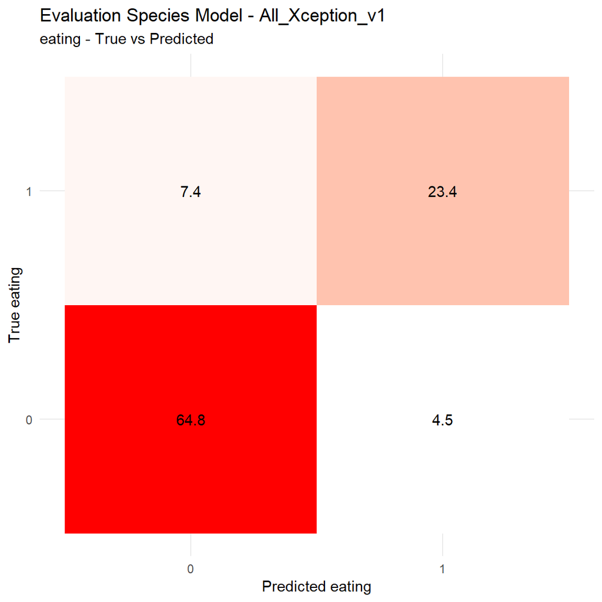

### Behavior Evaluation - Interacting

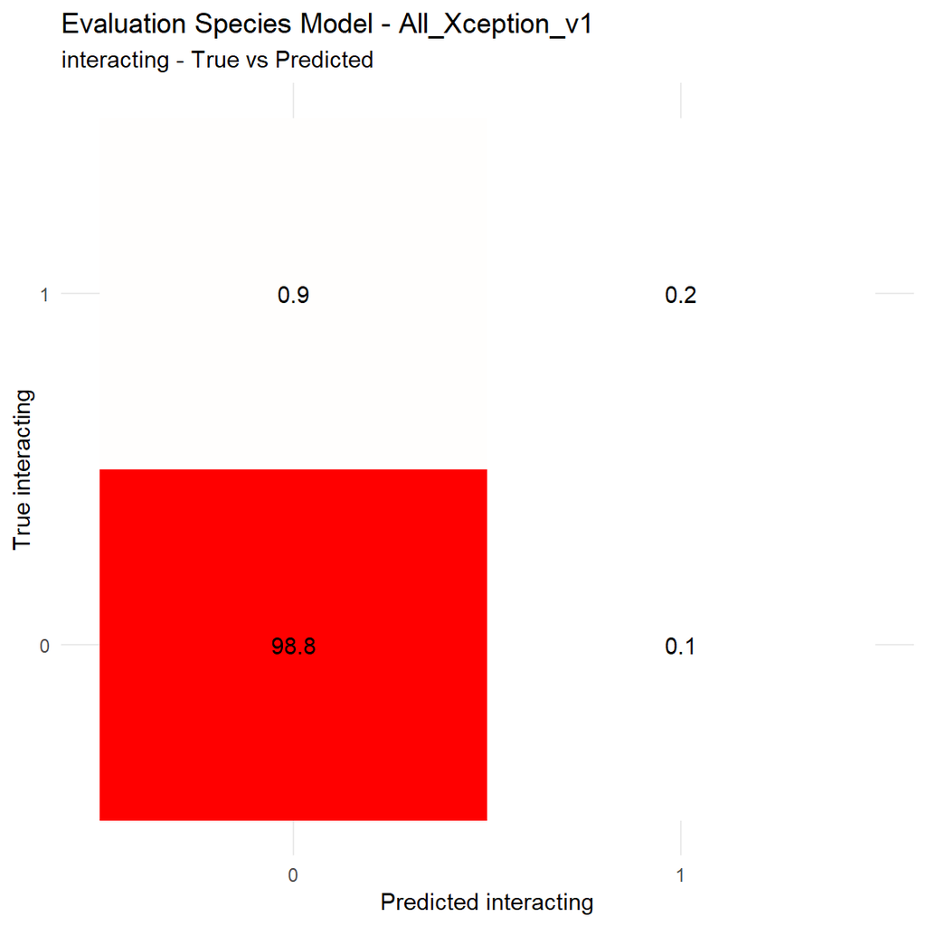

### Young Present

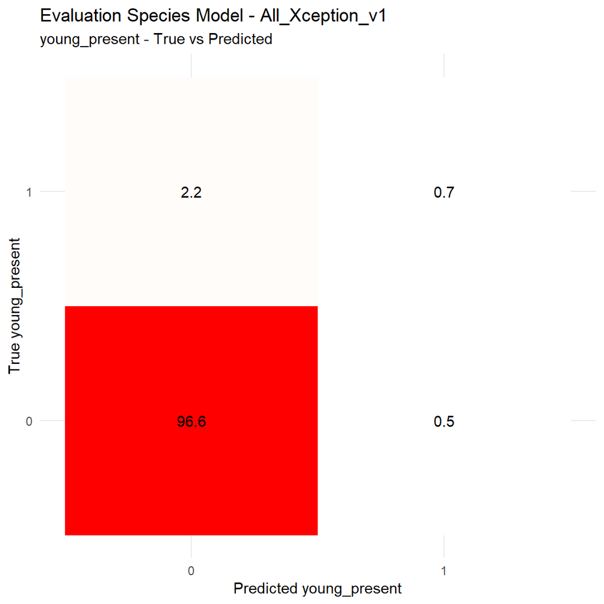